# Airbnb_AMS

```python
# Airbnb Case Amsterdam

import pandas as pd
import numpy as np
import seaborn as sns
sns.set()
import matplotlib.pyplot as plt
import plotly.graph_objs as go
import plotly.plotly as py
from plotly.offline import iplot, init_notebook_mode
import cufflinks
cufflinks.go_offline(connected=True)
init_notebook_mode(connected=True)
import folium
from folium.plugins import FastMarkerCluster
from sklearn.preprocessing import LabelEncoder
from sklearn.model_selection import cross_val_score, GridSearchCV
from sklearn.ensemble import RandomForestRegressor
from sklearn.preprocessing import MinMaxScaler
from matplotlib.ticker import FormatStrFormatter
from sklearn.model_selection import train_test_split
```

## 1. Preprocessing

### 1.1 Inspect data

```python
df = pd.read_csv("listings.csv")
```

```python
df.shape
```

```
(13849, 16)
```

```python
df.head()
```

|  | id | name | host_id | host_name | neighbourhood_group | neighbourhood | latitude | longitude | room_type | price | minimum_nights | number_of_reviews | last_review | reviews_per_month | calculated_host_listings_count | availability_365 |
| --- | --- | --- | --- | --- | --- | --- | --- | --- | --- | --- | --- | --- | --- | --- | --- | --- |
| 0 | 9784567 | nice Room in Amsterdam | 27280608 | Petra | NaN | Bijlmer-Oost | 52.323369 | 4.977730 | Private room | 95 | 1 | 5 | 2016-06-27 | 0.81 | 3 | 365 |
| 1 | 13163805 | Best cost benefit room near a metro station | 35491461 | Phillip | NaN | Bijlmer-Oost | 52.315635 | 4.978166 | Private room | 60 | 1 | 4 | 2016-06-27 | 4.00 | 1 | 77 |
| 2 | 3719167 | Nice room in A´dam SE near nature & heart centre | 18991270 | Maria | NaN | Bijlmer-Oost | 52.316711 | 4.986618 | Private room | 45 | 5 | 11 | 2016-01-02 | 0.48 | 1 | 23 |
| 3 | 13188367 | Private room 15min metro ride from city center | 73797940 | Diana | NaN | Bijlmer-Oost | 52.321204 | 4.976630 | Private room | 35 | 1 | 2 | 2016-05-31 | 1.62 | 1 | 10 |
| 4 | 4831606 | Room in Amsterdam in a new house!! Free Bicycle | 24314617 | Jorim | NaN | Bijlmer-Oost | 52.327270 | 4.967352 | Private room | 39 | 14 | 12 | 2016-03-22 | 0.65 | 1 | 338 |

```python
# data type
df.info()
```

```
<class 'pandas.core.frame.DataFrame'>
RangeIndex: 13849 entries, 0 to 13848
Data columns (total 16 columns):
id                                13849 non-null int64
name                              13849 non-null object
host_id                           13849 non-null int64
host_name                         13813 non-null object
neighbourhood_group               0 non-null float64
neighbourhood                     13849 non-null object
latitude                          13849 non-null float64
longitude                         13849 non-null float64
room_type                         13849 non-null object
price                             13849 non-null int64
minimum_nights                    13849 non-null int64
number_of_reviews                 13849 non-null int64
last_review                       11386 non-null object
reviews_per_month                 11386 non-null float64
calculated_host_listings_count    13849 non-null int64
availability_365                  13849 non-null int64
dtypes: float64(4), int64(7), object(5)
memory usage: 1.7+ MB
```

```python
df.describe()
```

|  | id | host_id | neighbourhood_group | latitude | longitude | price | minimum_nights | number_of_reviews | reviews_per_month | calculated_host_listings_count | availability_365 |
| --- | --- | --- | --- | --- | --- | --- | --- | --- | --- | --- | --- |
| count | 1.384900e+04 | 1.384900e+04 | 0.0 | 13849.000000 | 13849.000000 | 13849.000000 | 13849.000000 | 13849.000000 | 11386.000000 | 13849.000000 | 13849.000000 |
| mean | 7.414648e+06 | 2.210917e+07 | NaN | 52.365568 | 4.889059 | 132.837100 | 2.933136 | 15.426457 | 1.426771 | 6.254675 | 129.650444 |
| std | 4.226337e+06 | 2.119229e+07 | NaN | 0.015315 | 0.034308 | 105.267487 | 11.166251 | 29.832918 | 1.412092 | 22.764329 | 132.248811 |
| min | 2.818000e+03 | 3.159000e+03 | NaN | 52.290402 | 4.763264 | 10.000000 | 1.000000 | 0.000000 | 0.020000 | 1.000000 | 0.000000 |
| 25% | 3.728983e+06 | 5.590622e+06 | NaN | 52.355850 | 4.865537 | 89.000000 | 2.000000 | 1.000000 | 0.460000 | 1.000000 | 6.000000 |
| 50% | 7.555385e+06 | 1.402933e+07 | NaN | 52.365208 | 4.886427 | 115.000000 | 2.000000 | 6.000000 | 0.990000 | 1.000000 | 69.000000 |
| 75% | 1.126592e+07 | 3.451633e+07 | NaN | 52.374948 | 4.907372 | 150.000000 | 3.000000 | 16.000000 | 1.920000 | 1.000000 | 259.000000 |
| max | 1.382844e+07 | 8.152423e+07 | NaN | 52.428571 | 5.027689 | 8616.000000 | 1000.000000 | 416.000000 | 12.250000 | 156.000000 | 365.000000 |

### 1.2 Clean missing values

```python
missing_count = df.isnull().sum()
print(missing_count)
```

```
id                                    0
name                                  0
host_id                               0
host_name                            36
neighbourhood_group               13849
neighbourhood                         0
latitude                              0
longitude                             0
room_type                             0
price                                 0
minimum_nights                        0
number_of_reviews                     0
last_review                        2463
reviews_per_month                  2463
calculated_host_listings_count        0
availability_365                      0
dtype: int64
```

```python
missing_count = df.isnull().sum()
layout = go.Layout(title="Number of listings by neighbourhood",
                   autosize=True,
#                    width=500,
#                    height=250,
                   xaxis=go.layout.XAxis(
                        automargin=True,
                   ),
                   yaxis=go.layout.YAxis(
                        automargin=True,
                   ),
                  )
missing_count.iplot(layout=layout, kind='barh', color='grey')
```

[interactive chart not shown]

```python
# neighbourhodd_group totally misising so we can directly drop
# host_names not really interest us, we can drop it to
# as for reviews_per_month and last_review, we cann use pair-wise deletion

df = df.drop(['neighbourhood_group'], axis=1)
df.head()
```

|  | id | name | host_id | host_name | neighbourhood | latitude | longitude | room_type | price | minimum_nights | number_of_reviews | last_review | reviews_per_month | calculated_host_listings_count | availability_365 |
| --- | --- | --- | --- | --- | --- | --- | --- | --- | --- | --- | --- | --- | --- | --- | --- |
| 0 | 9784567 | nice Room in Amsterdam | 27280608 | Petra | Bijlmer-Oost | 52.323369 | 4.977730 | Private room | 95 | 1 | 5 | 2016-06-27 | 0.81 | 3 | 365 |
| 1 | 13163805 | Best cost benefit room near a metro station | 35491461 | Phillip | Bijlmer-Oost | 52.315635 | 4.978166 | Private room | 60 | 1 | 4 | 2016-06-27 | 4.00 | 1 | 77 |
| 2 | 3719167 | Nice room in A´dam SE near nature & heart centre | 18991270 | Maria | Bijlmer-Oost | 52.316711 | 4.986618 | Private room | 45 | 5 | 11 | 2016-01-02 | 0.48 | 1 | 23 |
| 3 | 13188367 | Private room 15min metro ride from city center | 73797940 | Diana | Bijlmer-Oost | 52.321204 | 4.976630 | Private room | 35 | 1 | 2 | 2016-05-31 | 1.62 | 1 | 10 |
| 4 | 4831606 | Room in Amsterdam in a new house!! Free Bicycle | 24314617 | Jorim | Bijlmer-Oost | 52.327270 | 4.967352 | Private room | 39 | 14 | 12 | 2016-03-22 | 0.65 | 1 | 338 |

```python
df.shape
```

```
(13849, 15)
```

### 1.3 Detect duplicated

```python
if df.duplicated().any():
    print("Duplicated rows detected!")
else:
    print("No duplicated rows detected.")
```

```
No duplicated rows detected.
```

### 1.4 Feature transformation

```python
# numeric dataframe for future use
df_numeric = df.copy()
df_numeric = df_numeric[['neighbourhood', 'room_type', 'price', 'minimum_nights',
                        'number_of_reviews', 'reviews_per_month', 'calculated_host_listings_count']]
df_numeric.head()
```

|  | neighbourhood | room_type | price | minimum_nights | number_of_reviews | reviews_per_month | calculated_host_listings_count |
| --- | --- | --- | --- | --- | --- | --- | --- |
| 0 | Bijlmer-Oost | Private room | 95 | 1 | 5 | 0.81 | 3 |
| 1 | Bijlmer-Oost | Private room | 60 | 1 | 4 | 4.00 | 1 |
| 2 | Bijlmer-Oost | Private room | 45 | 5 | 11 | 0.48 | 1 |
| 3 | Bijlmer-Oost | Private room | 35 | 1 | 2 | 1.62 | 1 |
| 4 | Bijlmer-Oost | Private room | 39 | 14 | 12 | 0.65 | 1 |

```python
# map room type to ordinal
room_type_mapping = {'Shared room' : 1,
                     'Private room' : 2,
                     'Entire home/apt' : 3}
df_numeric['room_type'] = df_numeric['room_type'].map(room_type_mapping)

# convert categorical
le = LabelEncoder()
df_numeric['neighbourhood'] = le.fit_transform(df_numeric['neighbourhood'])
df_numeric = df_numeric.dropna()
df_numeric.head()
```

|  | neighbourhood | room_type | price | minimum_nights | number_of_reviews | reviews_per_month | calculated_host_listings_count |
| --- | --- | --- | --- | --- | --- | --- | --- |
| 0 | 1 | 2 | 95 | 1 | 5 | 0.81 | 3 |
| 1 | 1 | 2 | 60 | 1 | 4 | 4.00 | 1 |
| 2 | 1 | 2 | 45 | 5 | 11 | 0.48 | 1 |
| 3 | 1 | 2 | 35 | 1 | 2 | 1.62 | 1 |
| 4 | 1 | 2 | 39 | 14 | 12 | 0.65 | 1 |

## 2 Data Exploration

### 2.1 Listings distribution

```python
# How many unique lisitngs are there in different neighbourhood
# number of listings by neighbourhood
neighbourhood_count = df['neighbourhood'].value_counts().sort_values(ascending=True)
```

```python
layout = go.Layout(title="Number of listings by neighbourhood",
                   autosize=True,
                   width=1000,
                   height=500,
                   xaxis=go.layout.XAxis(
                        title='Number of listings',
                        automargin=True,
                   ),
                   yaxis=go.layout.YAxis(
                        title='Neighbourhood',
                        automargin=True,
                   ),
                  )
neighbourhood_count.iplot(layout=layout, kind='barh')
```

[interactive chart not shown]

```python
lats = df['latitude'].tolist()
lons = df['longitude'].tolist()
locations = list(zip(lats, lons))

listing_map = folium.Map(location=[52.3680, 4.9036], zoom_start=11.5)
FastMarkerCluster(data=locations).add_to(listing_map)
listing_map
```

[interactive chart not shown]

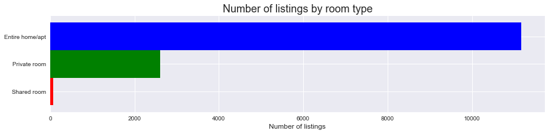

```python
# number of listings by room type
room_type_count = df['room_type']. value_counts().sort_values(ascending=True)
room_type_count.plot.barh(figsize=(15, 3), width=1, color=['r','g','b'])
plt.title('Number of listings by room type', fontsize=18)
plt.xlabel('Number of listings', fontsize=12)
plt.show()
```

```python
# average availability next year by neighbourhood
avg_avail_neighbourhood = df.groupby('neighbourhood')['availability_365'].sum().sort_values(ascending=True)
layout = go.Layout(title="Availability next year by neighbourhood",
                   autosize=True,
                   width=1000,
                   height=500,
                   xaxis=go.layout.XAxis(
                        title='Sum of available days',
                        automargin=True,
                   ),
                   yaxis=go.layout.YAxis(
                        automargin=True,
                   ),
                  )
avg_avail_neighbourhood.iplot(layout=layout, kind='barh')
```

[interactive chart not shown]

### 2.2 Price

#### 2.2.1 Price distribution

```python
# price boxplot
trace0 = go.Box(
    y=df['price'],
    name='price',
)

data = [trace0]
iplot(data)
```

[interactive chart not shown]

```python
# price boxplot
trace0 = go.Box(
    y=np.log(df['price']),
    name='log price',
)

data = [trace0]
iplot(data)
```

[interactive chart not shown]

```python
# df_no_extreme = df.drop(index=9395)
```

```python
# # Plot a histogram of price
# trace = go.Histogram(x=df["price"],
#                      marker=dict(color="red"))

# layout = go.Layout(xaxis=dict(title="Price"),
#                    yaxis=dict(title="Num of Listings"),
#                    title="Histogram of Price")
# data = [trace]
# fig = go.Figure(data=data,layout=layout)
# iplot(fig)
```

the histogram is skewed, so we do the logarithm

```python
# Plot a histogram of price
trace = go.Histogram(x=np.log(df["price"]),
                     marker=dict(color="red"))

layout = go.Layout(xaxis=dict(title="Price (log)"),
                   yaxis=dict(title="Num of Listings"),
                   title="Histogram of Price")
data = [trace]
fig = go.Figure(data=data,layout=layout)
iplot(fig)
```

[interactive chart not shown]

#### 2.2.2 Price outlier inspect

```python
def highlight_extreme_outliers(value):
    '''
    highlight the extreme in a Series yellow.
    '''
    is_extreme = value > 8000
    return ['background-color: red' if v else '' for v in is_extreme]
```

```python
# keep only the ones that are out of +3 to -3 standard deviations in the column 'price'.
price_outliers = df[~(np.abs(df['price']-df['price'].mean())<(3*df['price'].std()))].sort_values('price', ascending=False)
price_outliers.style.apply(highlight_extreme_outliers, subset=['price'])
```

|  | id | name | host_id | host_name | neighbourhood | latitude | longitude | room_type | price | minimum_nights | number_of_reviews | last_review | reviews_per_month | calculated_host_listings_count | availability_365 |
| --- | --- | --- | --- | --- | --- | --- | --- | --- | --- | --- | --- | --- | --- | --- | --- |
| 9395 | 12793635 | Museum plein/van Gogh/Rijks | 69667343 | Maurits | Zuid | 52.3591 | 4.87871 | Entire home/apt | 8616 | 1 | 0 | nan | nan | 1 | 365 |
| 3266 | 4673471 | Sailingship Succes in Amsterdam | 24174723 | Naupar | Oostelijk Havengebied - Indische Buurt | 52.3802 | 4.92561 | Entire home/apt | 1442 | 2 | 0 | nan | nan | 8 | 276 |
| 642 | 5587500 | Faralda Crane Hotel Amsterdam | 21831151 | Faralda | Oud-Noord | 52.3995 | 4.89468 | Entire home/apt | 1307 | 1 | 1 | 2015-10-18 | 0.11 | 4 | 365 |
| 1352 | 785244 | Vila Catedralus - whole house | 4139821 | David | Centrum-West | 52.3773 | 4.8919 | Entire home/apt | 1253 | 2 | 16 | 2016-04-24 | 0.39 | 4 | 341 |
| 9843 | 4394074 | Schitterend Herenhuis op A-locatie! | 22806302 | Danielle | Zuid | 52.3547 | 4.87198 | Entire home/apt | 977 | 3 | 7 | 2015-10-18 | 0.38 | 1 | 355 |
| 2705 | 529174 | LUXURY GROUP HOUSE D | 8003829 | Christian | Centrum-West | 52.3691 | 4.88428 | Entire home/apt | 922 | 4 | 47 | 2016-06-21 | 0.99 | 2 | 157 |
| 13308 | 6913671 | Woning te huur voor 6 maanden! | 36231152 | Nilay | Geuzenveld - Slotermeer | 52.3723 | 4.81974 | Entire home/apt | 901 | 1 | 0 | nan | nan | 1 | 0 |
| 9146 | 12535339 | Amazing family villa - best area of Amsterdam! | 344280 | Boukje | Zuid | 52.347 | 4.87934 | Entire home/apt | 900 | 4 | 0 | nan | nan | 1 | 253 |
| 1774 | 3332424 | City Centre - renovated Canal House | 11224822 | Edwin | Centrum-West | 52.3663 | 4.88074 | Entire home/apt | 897 | 4 | 4 | 2015-12-27 | 0.17 | 1 | 323 |
| 1140 | 10666791 | Beautiful Family House on Canals! | 55097200 | Elsje | Centrum-West | 52.3717 | 4.88129 | Entire home/apt | 802 | 5 | 5 | 2016-06-05 | 1.63 | 1 | 63 |
| 6000 | 10177152 | Private room Amsterdam Center | 51654525 | Heleen | Watergraafsmeer | 52.3542 | 4.92887 | Private room | 802 | 3 | 0 | nan | nan | 1 | 0 |
| 1555 | 2059078 | ★Central Canal House - Whole House★ | 9957140 | Max | Centrum-West | 52.3699 | 4.89607 | Entire home/apt | 801 | 2 | 5 | 2016-05-16 | 0.27 | 6 | 47 |
| 4395 | 7061230 | unique canalhouse! | 8027754 | Toon | Centrum-Oost | 52.366 | 4.90765 | Entire home/apt | 796 | 4 | 9 | 2016-05-27 | 0.92 | 1 | 133 |
| 2466 | 7317427 | Big house in the centre of A'dam! | 16800846 | Berend | Centrum-West | 52.379 | 4.88091 | Entire home/apt | 751 | 3 | 3 | 2016-04-24 | 0.26 | 1 | 35 |
| 7704 | 10086914 | Amsterdam Riverside - 10p | 6427770 | Michael | De Pijp - Rivierenbuurt | 52.3428 | 4.90823 | Entire home/apt | 751 | 1 | 0 | nan | nan | 1 | 0 |
| 718 | 4399067 | De Cornelia, large houseboat | 22837110 | Paul | Oud-Noord | 52.389 | 4.9379 | Entire home/apt | 701 | 2 | 27 | 2016-06-30 | 1.77 | 1 | 317 |
| 9935 | 6717883 | Museum Area Luxury Family Residence | 16795608 | Manon | Zuid | 52.3544 | 4.88359 | Entire home/apt | 701 | 2 | 12 | 2016-06-19 | 1.38 | 1 | 196 |
| 3674 | 7922709 | LuxuryMonument opposite Rijksmuseum | 31495460 | Y | Centrum-Oost | 52.3614 | 4.88821 | Entire home/apt | 701 | 1 | 13 | 2016-07-02 | 1.4 | 2 | 332 |
| 8995 | 9993734 | 4-bedrooms house: Museum Square | 51340216 | Wp | Zuid | 52.3558 | 4.88205 | Entire home/apt | 701 | 2 | 3 | 2016-05-06 | 0.47 | 1 | 85 |
| 4488 | 12596322 | 'THE MANSION' 15P Private Hotel | 68338234 | Lin | Centrum-Oost | 52.3639 | 4.88081 | Entire home/apt | 700 | 2 | 3 | 2016-06-22 | 1.88 | 7 | 165 |
| 5779 | 10245597 | THE GIANT - 7 bedrooms, 4 bathrooms | 8558897 | Alexander | Oud-Oost | 52.3604 | 4.9265 | Entire home/apt | 677 | 2 | 6 | 2016-06-17 | 1.34 | 33 | 299 |
| 4417 | 8109857 | city center house amsterdam | 42822106 | Bommel | Centrum-Oost | 52.3624 | 4.89456 | Entire home/apt | 677 | 2 | 3 | 2016-01-03 | 0.3 | 2 | 365 |
| 6289 | 3927358 | Classic Sailing Ship " Store Baelt" | 20346940 | Heine | Westerpark | 52.393 | 4.88118 | Entire home/apt | 661 | 1 | 18 | 2016-04-04 | 0.88 | 1 | 142 |
| 11265 | 5093992 | Canal house (275m2) in a former parish, big garden | 26320053 | Rogier | De Baarsjes - Oud-West | 52.371 | 4.87345 | Entire home/apt | 651 | 2 | 2 | 2015-10-20 | 0.13 | 1 | 262 |
| 6293 | 780844 | Whole sailing ship for your group!! | 3357851 | Henri | Westerpark | 52.3928 | 4.88345 | Entire home/apt | 651 | 2 | 6 | 2016-04-29 | 0.23 | 6 | 185 |
| 1432 | 11367985 | 8 person apartment centre Amsterdam | 51988897 | Joep | Centrum-West | 52.373 | 4.88713 | Entire home/apt | 651 | 3 | 1 | 2016-03-08 | 0.25 | 1 | 0 |
| 6788 | 6340512 | Welcome aboard sailing vessel MANNA | 29574069 | Viola | Westerpark | 52.3927 | 4.88204 | Entire home/apt | 641 | 1 | 0 | nan | nan | 2 | 115 |
| 1944 | 9554582 | Canal House city centre with garden | 49475014 | Minouk | Centrum-West | 52.3768 | 4.88799 | Entire home/apt | 626 | 4 | 1 | 2016-01-02 | 0.16 | 1 | 15 |
| 8074 | 12503509 | Spacious Houseboat on the Amstel | 55011454 | Mattijs | De Pijp - Rivierenbuurt | 52.3541 | 4.9076 | Entire home/apt | 601 | 3 | 0 | nan | nan | 1 | 75 |
| 849 | 12377200 | Urban Villa @IJmeer close to centre | 1181104 | Jeroen | IJburg - Zeeburgereiland | 52.3548 | 4.99058 | Entire home/apt | 601 | 3 | 0 | nan | nan | 1 | 24 |

[output cut: 93 more lines]

#### 2.2.3 Important features to price

```python
def plot_feature_importances(dataset_name, features, importances, indices):
    """Plot the 15 most important features."""
    a = 0.8
    f_sub = []
    max_features = 20

    for f in range(min(len(features), max_features)):
            f_sub.append(f)

    # Create a figure of given size
    fig = plt.figure(figsize=(8, 6))
    ax = fig.add_subplot(111)
    # Set title
    ttl = dataset_name

    df = pd.DataFrame(importances[indices[f_sub]][::-1])
    df.plot(kind='barh', ax=ax, alpha=a, legend=False, edgecolor='w',
            title=ttl, color = [plt.cm.viridis(np.arange(len(df))*10)])

    # Remove grid lines and plot frame
    ax.grid(False)
    ax.set_frame_on(False)

    # Customize title
    ax.set_title(ax.get_title(), fontsize=14, alpha=a, ha='left', x=0, y=1.0)
    plt.subplots_adjust(top=0.9)

    # Customize x tick lables
    ax.xaxis.set_major_formatter(FormatStrFormatter('%.3f'))
    ax.locator_params(axis='x', tight=True, nbins=5)

    # Customize y tick labels
    yticks = np.array(features)[indices[f_sub]][::-1]
    ax.set_yticklabels(yticks, fontsize=12, alpha=a)
    ax.yaxis.set_tick_params(pad=2)
    ax.yaxis.set_ticks_position('none')
    ax.set_ylim(ax.get_ylim()[0]-0.5, ax.get_ylim()[1]+0.5)

    # Set x axis text
    xlab = 'Feature importance'
    ax.set_xlabel(xlab, fontsize=12, alpha=a)
    ax.xaxis.set_label_coords(0.5, -0.1)

    # Set y axis text
    ylab = 'Feature'
    ax.set_ylabel(ylab, fontsize=12, alpha=a)
    plt.show()
```

```python
y = df_numeric['price']
X = df_numeric[df_numeric.columns.difference(['price'])]
X_train, X_valid, y_train, y_valid = train_test_split(X, y, test_size = 0.8, random_state = 42)
```

```python
rf = RandomForestRegressor(n_estimators = 100,
                           max_depth = 20,
                           n_jobs = -1,
                           oob_score = True,
                           bootstrap = True,
                           random_state = 42)
rf.fit(X_train, y_train)

print('R^2 Training Score: {:.2f} \nOOB Score: {:.2f} \nR^2 Validation Score: {:.2f}'.format(rf.score(X_train, y_train),
                                                                                             rf.oob_score_,
                                                                                             rf.score(X_valid, y_valid)))
```

```
R^2 Training Score: 0.85
OOB Score: 0.07
R^2 Validation Score: 0.09
```

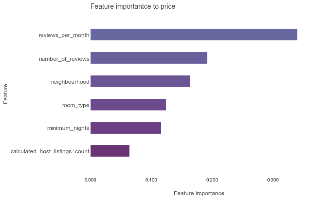

```python
importances = rf.feature_importances_
indices = np.argsort(importances)[::-1]
plot_feature_importances("Feature importantce to price", X.columns, importances, indices)
```

#### 2.2.4 price and room type

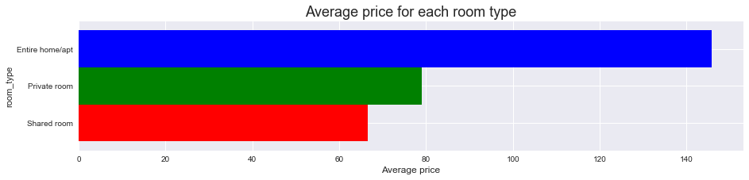

```python
# average price by room type

avg_price_room = df.groupby('room_type')['price'].mean().sort_values(ascending=True)
avg_price_room.plot.barh(figsize=(15, 3), width=1, color=['r', 'g', 'b'])
plt.title('Average price for each room type', fontsize=18)
plt.xlabel('Average price', fontsize=12)
plt.show()
```

Entire room much more expensive than private room and shared room shared room also the same to private room

#### 2.2.4 price and neighbourhood

```python
# average price in each area

avg_price_neighbourhood = df.groupby('neighbourhood')['price'].mean().sort_values(ascending=True)
layout = go.Layout(title="Average daily price by neighbourhood",
                   autosize=True,
                   width=1000,
                   height=500,
                   xaxis=go.layout.XAxis(
                        title='Average daily price',
                        automargin=True,
                   ),

                   yaxis=go.layout.YAxis(
                        automargin=True,
                   ),
                  )
avg_price_neighbourhood.iplot(layout=layout, kind='barh')
```

[interactive chart not shown]

city center most experiensive

### 2.3 Number of reviews (popular)

Listings with large number of reviews are popular (otherwise won't be many guests). However, to be noticed, small number of reviews doesn't mean the listing is not good, it may also because the listings are new.

```python
# Important features to number of reviews
# y = df_numeric['number_of_reviews']
# X = df_numeric[df_numeric.columns.difference(['number_of_reviews', 'reviews_per_month'])]
# X_train, X_valid, y_train, y_valid = train_test_split(X, y, test_size = 0.8, random_state = 42)

# rf = RandomForestRegressor(n_estimators = 100,
#                            max_depth = 5,
#                            n_jobs = -1,
#                            oob_score = True,
#                            bootstrap = True,
#                            random_state = 42)
# rf.fit(X_train, y_train)

# print('R^2 Training Score: {:.2f} \nOOB Score: {:.2f} \nR^2 Validation Score: {:.2f}'.format(rf.score(X_train, y_train),
#                                                                                              rf.oob_score_,
#                                                                                              rf.score(X_valid, y_valid)))

# importances = rf.feature_importances_
# indices = np.argsort(importances)[::-1]
# plot_feature_importances("Feature importantce to number of reviews", X.columns, importances, indices)
```

#### 2.3.1 number of reviews and price

```python
df_price_review = df[['price', 'number_of_reviews']]
df_price_review['log_price'] = np.log(df_price_review['price'])
df_price_review['log_price_interval'] = pd.cut(df_price_review['log_price'], 10, precision=1).astype(str)
df_price_review.head()
```

|  | price | number_of_reviews | log_price | log_price_interval |
| --- | --- | --- | --- | --- |
| 0 | 95 | 5 | 4.553877 | (4.3, 5.0] |
| 1 | 60 | 4 | 4.094345 | (3.7, 4.3] |
| 2 | 45 | 11 | 3.806662 | (3.7, 4.3] |
| 3 | 35 | 2 | 3.555348 | (3.0, 3.7] |
| 4 | 39 | 12 | 3.663562 | (3.7, 4.3] |

```python
# scatter plot
trace = go.Scatter(
    x = df_price_review['log_price'],
    y = df_price_review['number_of_reviews'],
    mode = 'markers'
)

data = [trace]
layout=go.Layout(xaxis={'title':'log price'}, yaxis={'title':'number of reviews'})
figure=go.Figure(data=data,layout=layout)

iplot(figure)
```

[interactive chart not shown]

```python
# average number of reviews by log price interval
avg_reviews_price = df_price_review.groupby('log_price_interval')['number_of_reviews'].mean()
layout = go.Layout(title="Average number of reviews by log price interval",
                   autosize=True,
                   width=1000,
                   height=500,
                   xaxis=go.layout.XAxis(
                        title='Log price interval',
                        automargin=True,
                   ),

                   yaxis=go.layout.YAxis(
                        automargin=True,
                   ),
                  )
avg_reviews_price.iplot(layout=layout, color='blue', kind='bar')
```

[interactive chart not shown]

#### 2.3.2 number of reviews by neighbourhood

```python
# average number of reviews by area
avg_reviews_neighbourhood = df.groupby('neighbourhood')['number_of_reviews'].mean().sort_values(ascending=True)
layout = go.Layout(title="Average number of reviews by neighbourhood",
                   autosize=True,
                   width=1000,
                   height=500,
                   xaxis=go.layout.XAxis(
                        title='Average number of reviews',
                        automargin=True,
                   ),

                   yaxis=go.layout.YAxis(
                        automargin=True,
                   ),
                  )
avg_reviews_neighbourhood.iplot(layout=layout, kind='barh')
```

[interactive chart not shown]

#### 2.3.3 number of reviews by room type

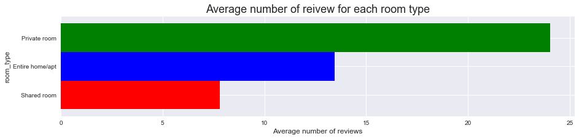

```python
# average number of reviews by room type

avg_reviews_room = df.groupby('room_type')['number_of_reviews'].mean().sort_values(ascending=True)
avg_reviews_room.plot.barh(figsize=(15, 3), width=1, color=['r', 'b', 'g'])
plt.title('Average number of reivew for each room type', fontsize=18)
plt.xlabel('Average number of reviews', fontsize=12)
plt.show()
```

### 2.4 Hosts

#### 2.4.1 Popular hosts

```python
df_popular_hosts = df[['name', 'host_id', 'host_name', 'number_of_reviews']].groupby('host_id')['number_of_reviews'].mean().sort_values(ascending=False)
```

```python
df_popular_hosts
```

```
host_id
186729      416.0
2182947     412.0
1979865     341.0
7867565     310.0
2331953     310.0
3556421     309.0
935742      305.0
1232843     305.0
1849988     291.0
276068      288.0
2586026     285.5
732783      278.0
1672823     273.0
935723      267.2
```

[output cut: 48 more lines]

#### 2.4.2 Listings owned by each host

```python
df_hosts = df[['host_id', 'host_name', 'calculated_host_listings_count']].sort_values('calculated_host_listings_count', ascending=False).drop_duplicates()
df_hosts
```

|  | host_id | host_name | calculated_host_listings_count |
| --- | --- | --- | --- |
| 938 | 669178 | Sammy | 156 |
| 2467 | 6999042 | Douwe&Niki | 128 |
| 11346 | 1464510 | Michiel And Jane | 98 |
| 11545 | 48703385 | Tillan | 71 |
| 6633 | 7002898 | Twan | 57 |
| 4280 | 4979621 | Jorrit&Dirk | 46 |
| 13837 | 517215 | Niels En Viv | 35 |
| 10463 | 1266717 | Team Key-BnB | 34 |
| 2474 | 8558897 | Alexander | 33 |
| 11338 | 8543234 | Priscilla | 28 |
| 12315 | 14574533 | Hotel Not Hotel | 23 |
| 10309 | 13405827 | Jan-Willem | 22 |
| 11002 | 14183886 | Luis | 19 |
| 8202 | 12856622 | Gert-Jan | 19 |
| 2550 | 7594884 | Duco | 17 |
| 5596 | 46691672 | Eva & Kobe | 17 |
| 2381 | 67005410 | Feliciano | 14 |
| 6859 | 40848145 | Scott | 13 |
| 3991 | 288514 | Hev | 11 |
| 3912 | 1324659 | Femke (Host My Home) | 11 |
| 4493 | 10905591 | Dirk | 11 |
| 1523 | 5796250 | Remco | 11 |
| 2651 | 44168250 | Ruben | 10 |
| 1750 | 1477248 | Niels | 10 |
| 9564 | 14162591 | ★Taia★ | 10 |
| 8806 | 3448622 | Cornelio | 10 |
| 1586 | 26295351 | Daniel | 10 |
| 5625 | 44723950 | Marianne & Casper | 9 |
| 4333 | 3899684 | Kiki & Chris | 9 |
| 2412 | 2028878 | City Centre | 9 |
| ... | ... | ... | ... |
| 5520 | 3254440 | Raisa | 1 |
| 5521 | 10633845 | Mark | 1 |
| 5522 | 10844398 | Ozlem | 1 |
| 5523 | 6352378 | Suzan | 1 |
| 5524 | 23686734 | Dirk | 1 |
| 5525 | 44106049 | Sarah | 1 |
| 5527 | 34884693 | Reinier & Irene | 1 |
| 5501 | 1223927 | Arjan | 1 |
| 5499 | 6578228 | Minoek | 1 |
| 5498 | 31102165 | Remy | 1 |
| 5485 | 48971793 | Maarten | 1 |
| 5477 | 325306 | Michiel | 1 |
| 5478 | 4793520 | Stephanie | 1 |
| 5479 | 47534178 | Jolette | 1 |
| 5480 | 43359318 | Emilie | 1 |
| 5481 | 44764068 | Steyn | 1 |
| 5482 | 17721346 | Gülçe | 1 |
| 5483 | 1444951 | Karin | 1 |
| 5484 | 9905611 | Suzanne | 1 |
| 5487 | 68103238 | Marlies | 1 |
| 5497 | 44262965 | Benedetta | 1 |
| 5488 | 34889003 | Louise | 1 |
| 5489 | 16178382 | Ramon | 1 |
| 5491 | 9966888 | Bas | 1 |
| 5492 | 13944172 | Jo-An | 1 |
| 5493 | 18629962 | Chesca | 1 |
| 5494 | 6239912 | Paola | 1 |
| 5495 | 3603628 | Brenda | 1 |
| 5496 | 23797298 | Michael | 1 |
| 13848 | 78791769 | Allard | 1 |

11464 rows × 3 columns

```python
df[df['host_name']=='Sammy']
```

|  | id | name | host_id | host_name | neighbourhood | latitude | longitude | room_type | price | minimum_nights | number_of_reviews | last_review | reviews_per_month | calculated_host_listings_count | availability_365 |
| --- | --- | --- | --- | --- | --- | --- | --- | --- | --- | --- | --- | --- | --- | --- | --- |
| 108 | 13630140 | COZY holiday apt. located trendy north + garden! | 669178 | Sammy | Noord-Oost | 52.392942 | 4.950952 | Entire home/apt | 79 | 2 | 0 | NaN | NaN | 156 | 10 |
| 139 | 13646589 | STUNNING family apt with balcony! | 669178 | Sammy | Noord-Oost | 52.395972 | 4.939867 | Entire home/apt | 149 | 2 | 0 | NaN | NaN | 156 | 28 |
| 160 | 13324378 | GREAT family apt. with a big garden + trampoline! | 669178 | Sammy | Noord-Oost | 52.390396 | 4.957286 | Entire home/apt | 149 | 2 | 0 | NaN | NaN | 156 | 14 |
| 258 | 13288525 | COZY apt. with terrace, vibrant trendy north! | 669178 | Sammy | Noord-West | 52.402611 | 4.917184 | Entire home/apt | 79 | 2 | 0 | NaN | NaN | 156 | 32 |
| 310 | 12635696 | STUNNING family home + terrace! | 669178 | Sammy | Noord-West | 52.406062 | 4.899825 | Entire home/apt | 149 | 2 | 2 | 2016-06-24 | 2.00 | 156 | 15 |
| 328 | 13090802 | Spacious house with 2 bedrooms + garden! | 669178 | Sammy | Noord-West | 52.409222 | 4.901337 | Entire home/apt | 149 | 2 | 0 | NaN | NaN | 156 | 20 |
| 330 | 13680265 | LOVELY family home with sunny garden! | 669178 | Sammy | Noord-West | 52.408937 | 4.900773 | Entire home/apt | 149 | 2 | 0 | NaN | NaN | 156 | 13 |
| 662 | 13646226 | LOVELY family home with garden! | 669178 | Sammy | Oud-Noord | 52.393070 | 4.915250 | Entire home/apt | 149 | 2 | 0 | NaN | NaN | 156 | 20 |
| 699 | 13183470 | LOVELY apt. with garden, 2 bedrooms! Vibrant N... | 669178 | Sammy | Oud-Noord | 52.388102 | 4.920634 | Entire home/apt | 149 | 2 | 0 | NaN | NaN | 156 | 23 |
| 828 | 13630849 | GORGEOUS studio with great view! | 669178 | Sammy | IJburg - Zeeburgereiland | 52.348476 | 5.005751 | Entire home/apt | 69 | 2 | 0 | NaN | NaN | 156 | 22 |
| 834 | 6908667 | Spacious apt. 2 bedrooms + garden | 669178 | Sammy | IJburg - Zeeburgereiland | 52.353295 | 5.004971 | Entire home/apt | 159 | 2 | 7 | 2015-08-08 | 0.59 | 156 | 33 |
| 835 | 13666308 | LOVELY 2 bedroom family home with balcony! | 669178 | Sammy | IJburg - Zeeburgereiland | 52.360915 | 4.975003 | Entire home/apt | 149 | 2 | 0 | NaN | NaN | 156 | 32 |
| 853 | 13681903 | LOVELY family apt. with roof terrace! | 669178 | Sammy | IJburg - Zeeburgereiland | 52.351157 | 4.999573 | Entire home/apt | 149 | 2 | 0 | NaN | NaN | 156 | 7 |
| 870 | 12351788 | GREAT apt. all you need! | 669178 | Sammy | IJburg - Zeeburgereiland | 52.361498 | 4.981749 | Entire home/apt | 149 | 2 | 1 | 2016-04-25 | 0.42 | 156 | 20 |
| 890 | 13307283 | LOVELY family apt. with Garden! | 669178 | Sammy | IJburg - Zeeburgereiland | 52.359849 | 4.982848 | Entire home/apt | 149 | 2 | 0 | NaN | NaN | 156 | 22 |
| 926 | 11898620 | GREAT family house with 4 bedrooms! | 669178 | Sammy | IJburg - Zeeburgereiland | 52.353582 | 4.989489 | Entire home/apt | 190 | 3 | 0 | NaN | NaN | 156 | 26 |
| 938 | 13052813 | COZY apt. located in sunny ijburg! | 669178 | Sammy | IJburg - Zeeburgereiland | 52.355530 | 4.999325 | Entire home/apt | 69 | 2 | 2 | 2016-06-27 | 2.00 | 156 | 5 |
| 948 | 13323390 | LOVELY house. with roof terrace and garden! | 669178 | Sammy | IJburg - Zeeburgereiland | 52.358372 | 4.993514 | Entire home/apt | 149 | 2 | 0 | NaN | NaN | 156 | 21 |
| 951 | 10603527 | Spacious family house with garden! | 669178 | Sammy | IJburg - Zeeburgereiland | 52.352817 | 5.001530 | Entire home/apt | 149 | 2 | 0 | NaN | NaN | 156 | 27 |
| 954 | 13518565 | GORGEOUS apt. with sunny balcony! | 669178 | Sammy | IJburg - Zeeburgereiland | 52.361338 | 4.991516 | Entire home/apt | 149 | 2 | 0 | NaN | NaN | 156 | 63 |
| 959 | 12240086 | WARM house, 2 bedrooms + garden! | 669178 | Sammy | IJburg - Zeeburgereiland | 52.349090 | 5.011024 | Entire home/apt | 159 | 2 | 2 | 2016-05-07 | 0.92 | 156 | 23 |
| 967 | 13386241 | SPACIOUS family apt. with terrace! | 669178 | Sammy | IJburg - Zeeburgereiland | 52.352321 | 4.999742 | Entire home/apt | 159 | 2 | 0 | NaN | NaN | 156 | 15 |
| 976 | 12696217 | GREAT 4 BEDROOM apt. + big balcony! | 669178 | Sammy | IJburg - Zeeburgereiland | 52.347767 | 5.011196 | Entire home/apt | 149 | 3 | 2 | 2016-06-19 | 2.00 | 156 | 18 |
| 986 | 13088632 | The Pink lady, 3 bedroom house + roof terrace! | 669178 | Sammy | IJburg - Zeeburgereiland | 52.351706 | 5.000739 | Entire home/apt | 149 | 2 | 0 | NaN | NaN | 156 | 14 |
| 991 | 13742817 | LOVELY 2 bedroom family home with terrace! | 669178 | Sammy | IJburg - Zeeburgereiland | 52.354574 | 4.999960 | Entire home/apt | 149 | 2 | 0 | NaN | NaN | 156 | 28 |
| 996 | 13741840 | LOVELY 2 bedroom apt. with great view! | 669178 | Sammy | IJburg - Zeeburgereiland | 52.369784 | 4.965603 | Entire home/apt | 149 | 2 | 0 | NaN | NaN | 156 | 8 |
| 1011 | 12527788 | MODERN apt. 2 bedrooms + balcony! | 669178 | Sammy | IJburg - Zeeburgereiland | 52.364287 | 4.987651 | Entire home/apt | 149 | 2 | 1 | 2016-05-08 | 0.52 | 156 | 44 |
| 1017 | 13214593 | COZY 2 bedroom apt. with front door terrace! | 669178 | Sammy | IJburg - Zeeburgereiland | 52.352577 | 5.008364 | Entire home/apt | 149 | 2 | 0 | NaN | NaN | 156 | 6 |
| 1057 | 13404516 | GORGEOUS 2 bedroom apt. with terrace! | 669178 | Sammy | IJburg - Zeeburgereiland | 52.360460 | 4.981210 | Entire home/apt | 149 | 2 | 0 | NaN | NaN | 156 | 17 |
| 1060 | 13502903 | GORGEOUS family home with roof terrace! | 669178 | Sammy | IJburg - Zeeburgereiland | 52.349675 | 4.998282 | Entire home/apt | 149 | 2 | 0 | NaN | NaN | 156 | 17 |
| ... | ... | ... | ... | ... | ... | ... | ... | ... | ... | ... | ... | ... | ... | ... | ... |
| 10228 | 13572536 | SUPER cozy apt + balcony in trendy old west | 669178 | Sammy | De Baarsjes - Oud-West | 52.362410 | 4.851456 | Entire home/apt | 79 | 2 | 0 | NaN | NaN | 156 | 36 |
| 10294 | 13052103 | MODERN apt. with a sunny balcony! Great location! | 669178 | Sammy | De Baarsjes - Oud-West | 52.361931 | 4.852306 | Entire home/apt | 79 | 2 | 0 | NaN | NaN | 156 | 4 |
| 10297 | 13269229 | COZY gorgeous apt. with patio! | 669178 | Sammy | De Baarsjes - Oud-West | 52.363138 | 4.859574 | Entire home/apt | 79 | 2 | 0 | NaN | NaN | 156 | 9 |
| 10313 | 13105402 | Spacious apt. + garden, 3 bedrooms, quiet street | 669178 | Sammy | De Baarsjes - Oud-West | 52.367618 | 4.849634 | Entire home/apt | 149 | 2 | 0 | NaN | NaN | 156 | 19 |
| 10389 | 13756962 | LOVELY apt. with terrace located west area! | 669178 | Sammy | De Baarsjes - Oud-West | 52.367775 | 4.854274 | Entire home/apt | 79 | 2 | 0 | NaN | NaN | 156 | 15 |
| 10446 | 13554914 | GORGEOUS ground level apt. + garden! | 669178 | Sammy | De Baarsjes - Oud-West | 52.367216 | 4.857579 | Entire home/apt | 79 | 2 | 0 | NaN | NaN | 156 | 6 |
| 10651 | 13200090 | BRILLIANT apt. with balcony! | 669178 | Sammy | De Baarsjes - Oud-West | 52.367596 | 4.854935 | Entire home/apt | 79 | 2 | 0 | NaN | NaN | 156 | 9 |
| 10843 | 12017190 | GREAT apt. hip west area, 2 bedrooms! | 669178 | Sammy | De Baarsjes - Oud-West | 52.364476 | 4.869801 | Entire home/apt | 169 | 2 | 2 | 2016-06-12 | 0.95 | 156 | 15 |
| 10931 | 13555523 | LOVELY spacious apt. with a balcony! | 669178 | Sammy | De Baarsjes - Oud-West | 52.365691 | 4.864945 | Entire home/apt | 79 | 2 | 0 | NaN | NaN | 156 | 3 |
| 11226 | 13776526 | STUNNING apt. located in trendy old-west area! | 669178 | Sammy | De Baarsjes - Oud-West | 52.364194 | 4.852976 | Entire home/apt | 79 | 2 | 0 | NaN | NaN | 156 | 60 |
| 11355 | 13681188 | AMAZING 2 bedroom apt. with balcony! | 669178 | Sammy | De Baarsjes - Oud-West | 52.370389 | 4.855213 | Entire home/apt | 149 | 2 | 0 | NaN | NaN | 156 | 127 |
| 11478 | 13089697 | Perfect apt. + garden, located in quiet street! | 669178 | Sammy | De Baarsjes - Oud-West | 52.367546 | 4.857319 | Entire home/apt | 79 | 2 | 0 | NaN | NaN | 156 | 14 |
| 11797 | 10422051 | GREAT apt. in trendy old-west area! | 669178 | Sammy | De Baarsjes - Oud-West | 52.368415 | 4.872102 | Entire home/apt | 124 | 2 | 15 | 2016-06-25 | 5.29 | 156 | 4 |
| 11871 | 13181830 | CHARMING apt. with balcony. old west area! | 669178 | Sammy | De Baarsjes - Oud-West | 52.371376 | 4.849942 | Entire home/apt | 79 | 2 | 0 | NaN | NaN | 156 | 1 |
| 11881 | 13183115 | GREAT apt. with Balcony and Roof terrace | 669178 | Sammy | De Baarsjes - Oud-West | 52.375037 | 4.862315 | Entire home/apt | 79 | 2 | 0 | NaN | NaN | 156 | 8 |
| 11896 | 13182288 | COZY apt. with balcony located Old-West area! | 669178 | Sammy | De Baarsjes - Oud-West | 52.365992 | 4.873740 | Entire home/apt | 79 | 2 | 0 | NaN | NaN | 156 | 28 |
| 12011 | 12098534 | LOVELY apt. in hip old-west! | 669178 | Sammy | De Baarsjes - Oud-West | 52.369362 | 4.855256 | Entire home/apt | 79 | 2 | 0 | NaN | NaN | 156 | 1 |
| 12078 | 13571850 | Fantastic family home + garden, in old west-area! | 669178 | Sammy | De Baarsjes - Oud-West | 52.369197 | 4.873176 | Entire home/apt | 149 | 2 | 0 | NaN | NaN | 156 | 32 |
| 12295 | 13306747 | COZY apt. with balcony at Old-West area! | 669178 | Sammy | De Baarsjes - Oud-West | 52.366133 | 4.861538 | Entire home/apt | 99 | 2 | 0 | NaN | NaN | 156 | 8 |
| 12513 | 10461770 | Chique apt, populair west area!! | 669178 | Sammy | De Baarsjes - Oud-West | 52.360427 | 4.855619 | Entire home/apt | 79 | 2 | 4 | 2016-02-23 | 0.83 | 156 | 45 |
| 12560 | 13180515 | LOVELY apt. with balcony, populair old-west area! | 669178 | Sammy | Bos en Lommer | 52.377612 | 4.846677 | Entire home/apt | 79 | 2 | 0 | NaN | NaN | 156 | 31 |
| 12640 | 13774325 | COZY 2 bedroom apt. with balcony, west area! | 669178 | Sammy | Bos en Lommer | 52.377816 | 4.849299 | Entire home/apt | 149 | 2 | 0 | NaN | NaN | 156 | 51 |
| 12729 | 13613809 | Fantastic 3 bedroom house, with a big garden! | 669178 | Sammy | Bos en Lommer | 52.383063 | 4.851487 | Entire home/apt | 159 | 2 | 0 | NaN | NaN | 156 | 24 |
| 12813 | 13088866 | FANTASTIC home with 3 bedrooms + garden! | 669178 | Sammy | Bos en Lommer | 52.379143 | 4.857246 | Entire home/apt | 159 | 2 | 0 | NaN | NaN | 156 | 20 |
| 12862 | 13289746 | TRENDY apt. with bath and balcony! | 669178 | Sammy | Bos en Lommer | 52.378784 | 4.856196 | Entire home/apt | 159 | 2 | 0 | NaN | NaN | 156 | 38 |
| 12876 | 11810432 | MODERN apt with great views! | 669178 | Sammy | Bos en Lommer | 52.376696 | 4.845101 | Entire home/apt | 99 | 2 | 5 | 2016-06-22 | 2.63 | 156 | 28 |
| 12882 | 12862423 | FANTASTIC home, 3 bedroom + garden! | 669178 | Sammy | Bos en Lommer | 52.378872 | 4.856287 | Entire home/apt | 149 | 2 | 0 | NaN | NaN | 156 | 36 |
| 13220 | 13215796 | STUNNING apt. 2 bedroom, with beautiful balcony! | 669178 | Sammy | Bos en Lommer | 52.378464 | 4.846455 | Entire home/apt | 149 | 2 | 0 | NaN | NaN | 156 | 30 |
| 13221 | 12747603 | GREAT apt. perfect for couple! | 669178 | Sammy | Bos en Lommer | 52.384435 | 4.852073 | Entire home/apt | 89 | 2 | 1 | 2016-05-22 | 0.68 | 156 | 26 |
| 13352 | 12258301 | Cozy place, amazing views + balcony | 669178 | Sammy | Geuzenveld - Slotermeer | 52.373296 | 4.835289 | Entire home/apt | 89 | 2 | 7 | 2016-05-24 | 2.56 | 156 | 4 |

156 rows × 15 columns

seems same house with diffrent names (last_review missing) or on a commmercial basis

## 3 Recommendations

### 3.1 Municipality

#### 3.1.1 Violations

In principle, holiday rental is only allowed if you are the owner of the house or houseboat.As a tenant, you can almost never rent your house or houseboat to others.  
You may only rent the house or houseboat occasionally 60 (2016)  
You can’t rent out your house or houseboat to more than four people at the same time.

#### 60 days limit

```python
# exceed 60 days rental limit
df_apt = df[df['room_type']=='Entire home/apt']
df_apt_old = df_apt[df_apt['number_of_reviews']>60]
df_exceed60 = df_apt_old[df_apt_old['reviews_per_month']>5]
df_exceed60 = df_exceed60[['name', 'room_type', 'price', 'number_of_reviews', 'reviews_per_month']]
df_exceed60
```

|  | name | room_type | price | number_of_reviews | reviews_per_month |
| --- | --- | --- | --- | --- | --- |
| 482 | charming dikehouse / green view | Entire home/apt | 125 | 94 | 7.56 |
| 589 | Modern Loft, near the city centre | Entire home/apt | 55 | 169 | 5.06 |
| 965 | Modern Houseboat/Large Roof Terrace | Entire home/apt | 85 | 142 | 6.26 |
| 1103 | Boat in the heart of the centre | Entire home/apt | 65 | 78 | 5.84 |
| 1299 | Singel Canal Apartment | Entire home/apt | 273 | 68 | 5.15 |
| 1326 | City View Apart. 3 in Center A'Dam! | Entire home/apt | 136 | 76 | 5.07 |
| 1451 | Stylish apartment in the citycenter | Entire home/apt | 99 | 192 | 6.85 |
| 1454 | Cosy little studio in a houseboat. | Entire home/apt | 100 | 86 | 5.33 |
| 1500 | nicely renovated Jordaan appartment | Entire home/apt | 99 | 197 | 6.59 |
| 1598 | 9 Streets City Centre Apartment | Entire home/apt | 140 | 129 | 8.96 |
| 1681 | Central - 2bathroom, canalhouse! | Entire home/apt | 200 | 75 | 6.50 |
| 1851 | HISTORICAL DOWNTOWN AMSTERDAM | Entire home/apt | 100 | 68 | 6.09 |
| 2002 | Luxurious spacious suite Jordaan | Entire home/apt | 149 | 81 | 6.08 |
| 2124 | The Backroom - Central private appt | Entire home/apt | 95 | 416 | 6.77 |
| 2129 | Unique studio on cutter 'Rosita' | Entire home/apt | 95 | 63 | 5.85 |
| 2162 | B&B Stars Dreams Stay Centrum | Entire home/apt | 175 | 153 | 6.27 |
| 2293 | marvelous apartment in City center | Entire home/apt | 146 | 77 | 5.21 |
| 2375 | cosy one room CANAL apartment | Entire home/apt | 115 | 76 | 6.91 |
| 2450 | Luxury apartment in city center | Entire home/apt | 99 | 123 | 5.03 |
| 2601 | B&B Central Amsterdam Centrum | Entire home/apt | 171 | 133 | 5.37 |
| 2625 | Modern canal house in city center | Entire home/apt | 120 | 86 | 6.04 |
| 3153 | Cosy Studio, with outdoor Swimming | Entire home/apt | 45 | 106 | 5.04 |
| 3678 | Amsterdam Rembrandtplein Apartment | Entire home/apt | 300 | 71 | 5.73 |
| 3684 | Leidseplein City Center Canal View | Entire home/apt | 120 | 62 | 5.17 |
| 3804 | Spacious, gorgeous monument. Centre | Entire home/apt | 119 | 318 | 6.71 |
| 3849 | Amsterdam Houseboat 'Centre' | Entire home/apt | 200 | 325 | 7.52 |
| 3948 | 17thC. studio center Amsterdam | Entire home/apt | 99 | 305 | 5.20 |
| 3949 | "The Library" canal area Amsterdam | Entire home/apt | 100 | 254 | 7.30 |
| 4216 | Add-Studio Six | Entire home/apt | 95 | 149 | 5.75 |
| 4226 | Houseboat in center of Amsterdam | Entire home/apt | 181 | 92 | 6.07 |
| ... | ... | ... | ... | ... | ... |
| 8312 | studio Museumquarter | Entire home/apt | 100 | 211 | 5.22 |
| 9094 | HOUSEBOAT NOVA 80m2 + FREE BIKES | Entire home/apt | 140 | 251 | 5.89 |
| 9186 | RUYSDAEL in the Museum Quarter | Entire home/apt | 85 | 189 | 6.91 |
| 9294 | Backpackers paradise | Entire home/apt | 45 | 69 | 6.29 |
| 9712 | 4 person apartment (free parking) | Entire home/apt | 149 | 92 | 5.04 |
| 9824 | Cozy Apartment In Museum District | Entire home/apt | 105 | 208 | 5.17 |
| 10198 | Light park view studio. | Entire home/apt | 105 | 81 | 7.25 |
| 10409 | Cosy and light apartment. | Entire home/apt | 50 | 86 | 5.89 |
| 10520 | Beautiful studio on great spot | Entire home/apt | 85 | 62 | 5.36 |
| 10749 | 2 BR, Ground Floor Apt. Canal View! | Entire home/apt | 111 | 322 | 6.38 |
| 10948 | atmospheric and spacious apartment | Entire home/apt | 99 | 91 | 7.00 |
| 11078 | In centre Modern & cozy apartment + garden | Entire home/apt | 97 | 88 | 5.16 |
| 11302 | Attic studio, great location center | Entire home/apt | 105 | 310 | 5.28 |
| 11306 | Super 4p apartment at top location | Entire home/apt | 130 | 95 | 6.29 |
| 11327 | Houseboat "Wooden shoe" Amsterdam | Entire home/apt | 146 | 61 | 6.08 |
| 11331 | private studio, balcony & 2 bikes! | Entire home/apt | 69 | 257 | 5.35 |
| 11475 | Modern two storey apt. Vondelpark | Entire home/apt | 160 | 209 | 5.12 |
| 11476 | All Amsterdam can offer CITY CENTER | Entire home/apt | 159 | 175 | 6.93 |
| 11590 | Canal View, Vondelpark (1 br, 4 pp) | Entire home/apt | 111 | 343 | 5.98 |
| 11708 | Cozy Studio 1 - Perfect for Couple! | Entire home/apt | 85 | 376 | 6.38 |
| 11755 | Sfeervol Amsterdam | Entire home/apt | 95 | 78 | 5.75 |
| 11882 | Attic room Centre quiet light cosy | Entire home/apt | 84 | 357 | 6.21 |
| 12161 | Centre Apartment quiet safe cosy | Entire home/apt | 79 | 253 | 5.93 |
| 12402 | New: Your home in Amsterdam | Entire home/apt | 120 | 107 | 5.84 |
| 12465 | Cozy Studio 2 - Perfect for Couple! | Entire home/apt | 87 | 271 | 6.91 |
| 12683 | Sunny Studio close to city centre | Entire home/apt | 74 | 308 | 5.14 |
| 12775 | city studio + terrace incl 2 bikes | Entire home/apt | 79 | 80 | 5.24 |
| 12822 | Sunny studio with balcony and WiFi | Entire home/apt | 74 | 351 | 5.76 |
| 13464 | Lovely cosy appartment Westside | Entire home/apt | 100 | 86 | 5.11 |
| 13633 | Trendy Spacious Apartment + Secure Parking Bay | Entire home/apt | 105 | 136 | 6.41 |

85 rows × 5 columns

```python
df_exceed60['extra_days_per_year'] = df_exceed60['reviews_per_month'] * 12 - 60
df_exceed60['estimated_extra_income'] = df_exceed60['extra_days_per_year'] * df_exceed60['price'] * 0.8
df_exceed60
```

|  | name | room_type | price | number_of_reviews | reviews_per_month | extra_days_per_year | estimated_extra_income |
| --- | --- | --- | --- | --- | --- | --- | --- |
| 482 | charming dikehouse / green view | Entire home/apt | 125 | 94 | 7.56 | 30.72 | 3072.000 |
| 589 | Modern Loft, near the city centre | Entire home/apt | 55 | 169 | 5.06 | 0.72 | 31.680 |
| 965 | Modern Houseboat/Large Roof Terrace | Entire home/apt | 85 | 142 | 6.26 | 15.12 | 1028.160 |
| 1103 | Boat in the heart of the centre | Entire home/apt | 65 | 78 | 5.84 | 10.08 | 524.160 |
| 1299 | Singel Canal Apartment | Entire home/apt | 273 | 68 | 5.15 | 1.80 | 393.120 |
| 1326 | City View Apart. 3 in Center A'Dam! | Entire home/apt | 136 | 76 | 5.07 | 0.84 | 91.392 |
| 1451 | Stylish apartment in the citycenter | Entire home/apt | 99 | 192 | 6.85 | 22.20 | 1758.240 |
| 1454 | Cosy little studio in a houseboat. | Entire home/apt | 100 | 86 | 5.33 | 3.96 | 316.800 |
| 1500 | nicely renovated Jordaan appartment | Entire home/apt | 99 | 197 | 6.59 | 19.08 | 1511.136 |
| 1598 | 9 Streets City Centre Apartment | Entire home/apt | 140 | 129 | 8.96 | 47.52 | 5322.240 |
| 1681 | Central - 2bathroom, canalhouse! | Entire home/apt | 200 | 75 | 6.50 | 18.00 | 2880.000 |
| 1851 | HISTORICAL DOWNTOWN AMSTERDAM | Entire home/apt | 100 | 68 | 6.09 | 13.08 | 1046.400 |
| 2002 | Luxurious spacious suite Jordaan | Entire home/apt | 149 | 81 | 6.08 | 12.96 | 1544.832 |
| 2124 | The Backroom - Central private appt | Entire home/apt | 95 | 416 | 6.77 | 21.24 | 1614.240 |
| 2129 | Unique studio on cutter 'Rosita' | Entire home/apt | 95 | 63 | 5.85 | 10.20 | 775.200 |
| 2162 | B&B Stars Dreams Stay Centrum | Entire home/apt | 175 | 153 | 6.27 | 15.24 | 2133.600 |
| 2293 | marvelous apartment in City center | Entire home/apt | 146 | 77 | 5.21 | 2.52 | 294.336 |
| 2375 | cosy one room CANAL apartment | Entire home/apt | 115 | 76 | 6.91 | 22.92 | 2108.640 |
| 2450 | Luxury apartment in city center | Entire home/apt | 99 | 123 | 5.03 | 0.36 | 28.512 |
| 2601 | B&B Central Amsterdam Centrum | Entire home/apt | 171 | 133 | 5.37 | 4.44 | 607.392 |
| 2625 | Modern canal house in city center | Entire home/apt | 120 | 86 | 6.04 | 12.48 | 1198.080 |
| 3153 | Cosy Studio, with outdoor Swimming | Entire home/apt | 45 | 106 | 5.04 | 0.48 | 17.280 |
| 3678 | Amsterdam Rembrandtplein Apartment | Entire home/apt | 300 | 71 | 5.73 | 8.76 | 2102.400 |
| 3684 | Leidseplein City Center Canal View | Entire home/apt | 120 | 62 | 5.17 | 2.04 | 195.840 |
| 3804 | Spacious, gorgeous monument. Centre | Entire home/apt | 119 | 318 | 6.71 | 20.52 | 1953.504 |
| 3849 | Amsterdam Houseboat 'Centre' | Entire home/apt | 200 | 325 | 7.52 | 30.24 | 4838.400 |
| 3948 | 17thC. studio center Amsterdam | Entire home/apt | 99 | 305 | 5.20 | 2.40 | 190.080 |
| 3949 | "The Library" canal area Amsterdam | Entire home/apt | 100 | 254 | 7.30 | 27.60 | 2208.000 |
| 4216 | Add-Studio Six | Entire home/apt | 95 | 149 | 5.75 | 9.00 | 684.000 |
| 4226 | Houseboat in center of Amsterdam | Entire home/apt | 181 | 92 | 6.07 | 12.84 | 1859.232 |
| ... | ... | ... | ... | ... | ... | ... | ... |
| 8312 | studio Museumquarter | Entire home/apt | 100 | 211 | 5.22 | 2.64 | 211.200 |
| 9094 | HOUSEBOAT NOVA 80m2 + FREE BIKES | Entire home/apt | 140 | 251 | 5.89 | 10.68 | 1196.160 |
| 9186 | RUYSDAEL in the Museum Quarter | Entire home/apt | 85 | 189 | 6.91 | 22.92 | 1558.560 |
| 9294 | Backpackers paradise | Entire home/apt | 45 | 69 | 6.29 | 15.48 | 557.280 |
| 9712 | 4 person apartment (free parking) | Entire home/apt | 149 | 92 | 5.04 | 0.48 | 57.216 |
| 9824 | Cozy Apartment In Museum District | Entire home/apt | 105 | 208 | 5.17 | 2.04 | 171.360 |
| 10198 | Light park view studio. | Entire home/apt | 105 | 81 | 7.25 | 27.00 | 2268.000 |
| 10409 | Cosy and light apartment. | Entire home/apt | 50 | 86 | 5.89 | 10.68 | 427.200 |
| 10520 | Beautiful studio on great spot | Entire home/apt | 85 | 62 | 5.36 | 4.32 | 293.760 |
| 10749 | 2 BR, Ground Floor Apt. Canal View! | Entire home/apt | 111 | 322 | 6.38 | 16.56 | 1470.528 |
| 10948 | atmospheric and spacious apartment | Entire home/apt | 99 | 91 | 7.00 | 24.00 | 1900.800 |
| 11078 | In centre Modern & cozy apartment + garden | Entire home/apt | 97 | 88 | 5.16 | 1.92 | 148.992 |
| 11302 | Attic studio, great location center | Entire home/apt | 105 | 310 | 5.28 | 3.36 | 282.240 |
| 11306 | Super 4p apartment at top location | Entire home/apt | 130 | 95 | 6.29 | 15.48 | 1609.920 |
| 11327 | Houseboat "Wooden shoe" Amsterdam | Entire home/apt | 146 | 61 | 6.08 | 12.96 | 1513.728 |
| 11331 | private studio, balcony & 2 bikes! | Entire home/apt | 69 | 257 | 5.35 | 4.20 | 231.840 |
| 11475 | Modern two storey apt. Vondelpark | Entire home/apt | 160 | 209 | 5.12 | 1.44 | 184.320 |
| 11476 | All Amsterdam can offer CITY CENTER | Entire home/apt | 159 | 175 | 6.93 | 23.16 | 2945.952 |
| 11590 | Canal View, Vondelpark (1 br, 4 pp) | Entire home/apt | 111 | 343 | 5.98 | 11.76 | 1044.288 |
| 11708 | Cozy Studio 1 - Perfect for Couple! | Entire home/apt | 85 | 376 | 6.38 | 16.56 | 1126.080 |
| 11755 | Sfeervol Amsterdam | Entire home/apt | 95 | 78 | 5.75 | 9.00 | 684.000 |
| 11882 | Attic room Centre quiet light cosy | Entire home/apt | 84 | 357 | 6.21 | 14.52 | 975.744 |
| 12161 | Centre Apartment quiet safe cosy | Entire home/apt | 79 | 253 | 5.93 | 11.16 | 705.312 |
| 12402 | New: Your home in Amsterdam | Entire home/apt | 120 | 107 | 5.84 | 10.08 | 967.680 |
| 12465 | Cozy Studio 2 - Perfect for Couple! | Entire home/apt | 87 | 271 | 6.91 | 22.92 | 1595.232 |
| 12683 | Sunny Studio close to city centre | Entire home/apt | 74 | 308 | 5.14 | 1.68 | 99.456 |
| 12775 | city studio + terrace incl 2 bikes | Entire home/apt | 79 | 80 | 5.24 | 2.88 | 182.016 |
| 12822 | Sunny studio with balcony and WiFi | Entire home/apt | 74 | 351 | 5.76 | 9.12 | 539.904 |
| 13464 | Lovely cosy appartment Westside | Entire home/apt | 100 | 86 | 5.11 | 1.32 | 105.600 |
| 13633 | Trendy Spacious Apartment + Secure Parking Bay | Entire home/apt | 105 | 136 | 6.41 | 16.92 | 1421.280 |

85 rows × 7 columns

#### Subletting

```python
df_sublet = df[df['name'].str.contains('student', regex=False)]
df_sublet
```

|  | id | name | host_id | host_name | neighbourhood | latitude | longitude | room_type | price | minimum_nights | number_of_reviews | last_review | reviews_per_month | calculated_host_listings_count | availability_365 |
| --- | --- | --- | --- | --- | --- | --- | --- | --- | --- | --- | --- | --- | --- | --- | --- |
| 41 | 13779421 | Short stay room in Amsterdam (in student house) | 80899279 | Ruben | Bijlmer-Oost | 52.326430 | 4.982602 | Private room | 27 | 1 | 0 | NaN | NaN | 1 | 364 |
| 803 | 12255457 | studenten kamer verhuur, 2 weken | 65991515 | Niene | Oud-Noord | 52.393074 | 4.912842 | Private room | 30 | 22 | 0 | NaN | NaN | 1 | 20 |
| 9159 | 13757750 | Large rooftop room for Jewish travelers or stu... | 16980515 | Viktor | Zuid | 52.348111 | 4.879821 | Private room | 70 | 2 | 0 | NaN | NaN | 1 | 33 |
| 13414 | 13760191 | Cozy student room with access to a belcony | 80637547 | Vera | Slotervaart | 52.356102 | 4.824416 | Private room | 39 | 2 | 0 | NaN | NaN | 2 | 29 |
| 13420 | 7730221 | Cozy student room | 40620686 | Belen | Slotervaart | 52.350677 | 4.844827 | Private room | 50 | 1 | 10 | 2016-06-27 | 1.63 | 1 | 3 |

#### Max 4 people at one time

```python
df_exceed4ppl = df[df['name'].str.contains('pers', regex=False)]
df_exceed4ppl = df_exceed4ppl[df_exceed4ppl['name'].str.contains('5|6|7|8')]
df_exceed4ppl
```

|  | id | name | host_id | host_name | neighbourhood | latitude | longitude | room_type | price | minimum_nights | number_of_reviews | last_review | reviews_per_month | calculated_host_listings_count | availability_365 |
| --- | --- | --- | --- | --- | --- | --- | --- | --- | --- | --- | --- | --- | --- | --- | --- |
| 838 | 11000373 | Familyhouse 4-6 pers - Free Parking | 56942995 | Erika | IJburg - Zeeburgereiland | 52.356417 | 4.998723 | Entire home/apt | 200 | 2 | 2 | 2016-05-29 | 0.50 | 1 | 19 |
| 1004 | 6826794 | Deluxe waterfront villa, 4-8 pers. | 28640347 | Marc & Ellen | IJburg - Zeeburgereiland | 52.353439 | 4.993091 | Entire home/apt | 165 | 2 | 1 | 2015-07-22 | 0.09 | 2 | 187 |
| 1432 | 11367985 | 8 person apartment centre Amsterdam | 51988897 | Joep | Centrum-West | 52.373002 | 4.887134 | Entire home/apt | 651 | 3 | 1 | 2016-03-08 | 0.25 | 1 | 0 |
| 2468 | 9840461 | Redlight District! app. (6/7 pers.) | 17957337 | Elmer | Centrum-West | 52.372130 | 4.899411 | Entire home/apt | 496 | 2 | 1 | 2016-01-02 | 0.16 | 1 | 0 |
| 3183 | 11263224 | Spacious apartment 4-6 persons | 58798486 | Owner | Oostelijk Havengebied - Indische Buurt | 52.377594 | 4.926632 | Entire home/apt | 200 | 5 | 5 | 2016-05-30 | 1.11 | 1 | 45 |
| 3292 | 3885680 | Room for max 5 persons | 20004778 | Saab | Oostelijk Havengebied - Indische Buurt | 52.376463 | 4.935279 | Private room | 120 | 1 | 22 | 2016-06-06 | 0.97 | 2 | 341 |
| 3387 | 10877893 | Room for max 7 persons on Java/KNSM | 56354281 | Sem | Oostelijk Havengebied - Indische Buurt | 52.377957 | 4.935609 | Entire home/apt | 120 | 2 | 5 | 2016-06-27 | 1.27 | 1 | 352 |
| 5938 | 9932417 | Nice apt Eastern area for 4-8 pers | 50433218 | Ricardo | Watergraafsmeer | 52.355866 | 4.933062 | Entire home/apt | 120 | 2 | 0 | NaN | NaN | 1 | 0 |
| 6175 | 13562304 | Gezellig gezinshuis voor 7 personen. | 78152639 | Inge | Gaasperdam - Driemond | 52.300259 | 4.998834 | Entire home/apt | 142 | 2 | 0 | NaN | NaN | 1 | 17 |
| 7052 | 9542122 | Nice spacious apartment 4-6 pers! | 47957952 | Lucas | Westerpark | 52.378734 | 4.870301 | Entire home/apt | 199 | 5 | 1 | 2016-03-13 | 0.26 | 1 | 0 |
| 8128 | 3227864 | Sunny, cosy apartment for 2-5 pers | 15037548 | Sonja | De Pijp - Rivierenbuurt | 52.353569 | 4.901545 | Entire home/apt | 200 | 2 | 8 | 2016-05-01 | 0.60 | 1 | 253 |
| 8163 | 9518694 | ideal Apartment for 2 persons 45m2 | 49318956 | Ronald | De Pijp - Rivierenbuurt | 52.355624 | 4.897327 | Entire home/apt | 96 | 2 | 24 | 2016-06-27 | 3.19 | 1 | 18 |
| 9606 | 9766033 | BIG 6 person (family) apartment | 25164908 | Laura | Zuid | 52.347543 | 4.847599 | Entire home/apt | 159 | 4 | 4 | 2016-05-09 | 0.65 | 6 | 166 |
| 9998 | 13719611 | Comfortable apartment in A'dam South 1-6 persons | 73360881 | Bart | Buitenveldert - Zuidas | 52.332203 | 4.873884 | Entire home/apt | 276 | 2 | 0 | NaN | NaN | 1 | 3 |
| 10335 | 1277909 | Lovely cozy (95m) apartement Amsterdam, 4 persons | 6954442 | Gilles | De Baarsjes - Oud-West | 52.361496 | 4.854891 | Entire home/apt | 100 | 2 | 0 | NaN | NaN | 1 | 11 |
| 13427 | 13791171 | 2 bedroom flat for up to 6 persons | 36223203 | Bastian | Slotervaart | 52.354180 | 4.840176 | Entire home/apt | 136 | 2 | 0 | NaN | NaN | 1 | 0 |
| 13810 | 13760435 | Amsterdam een heerlijk ruim huis voor 6 personen | 80465080 | Nine | De Aker - Nieuw Sloten | 52.346910 | 4.792006 | Entire home/apt | 181 | 7 | 0 | NaN | NaN | 1 | 15 |
| 13847 | 13722497 | Spacious, split level appt 5 pers | 19237729 | Marco | Watergraafsmeer | 52.335153 | 4.941866 | Entire home/apt | 175 | 1 | 0 | NaN | NaN | 1 | 276 |

People caught breaking the rules can be fined €6,000 for a first offence, mounting to €20,000 for repeated illegal rentals. -- DutchNews.nl

#### 3.1.3 Invest hotels

number of reviews by neighbourhood and number of listings by neighbourhood

### 3.2 Tourists

Q1 which area has the most available listings in the next year  
Q2 which airbnb cheap (room type, area)  
Q3 which area popular  
Q4 popular hosts

### 3.3 Landlord

Q1 ROI  
Q2 how to make your airbnb popular  
Q3 which neighbourhood is a good choice to let listing?

ROI = (Current Value - Cost) / Cost  
Current Value = Price * Days  
Cost = House Price + Tax + Others(Internet, water etc.)